# Housing Shortage Analysis Part 2

Blake Underwood

2024-07-16

# Iowa Housing Shortage futher analysis

## housing a population correlation

When looking at the cities of Iowa, we see a direct correlation between the change in housing supply and the change in population, and we can see that there does appear to be more cities with a slighter greater change in housing supply than population.

```r
library(tidycensus)
library(dplyr)

# data for housing and population statistics
get_population_housing_data <- function(year) {
  get_acs(
    geography = "place",
    variables = c(population = "B01003_001", housing_units = "B25001_001"),
    year = year,
    state = "IA",
    survey = "acs5"
  ) %>%
    mutate(year = year)
}


data_2012 <- get_population_housing_data(2012)
data_2022 <- get_population_housing_data(2022)

# cleaning data
clean_name <- function(name) {
  sub(" city, Iowa", "", name)
}

data_2012 <- data_2012 %>% mutate(NAME = clean_name(NAME))
data_2022 <- data_2022 %>% mutate(NAME = clean_name(NAME))

merged_data <- data_2012 %>%
  select(NAME, variable, estimate_2012 = estimate) %>%
  inner_join(
    data_2022 %>% select(NAME, variable, estimate_2022 = estimate),
    by = c("NAME", "variable")
  )

population_data <- merged_data %>% filter(variable == "population")
housing_data <- merged_data %>% filter(variable == "housing_units")

# Calculate percentage changes
final_data <- population_data %>%
  select(NAME, estimate_2012_population = estimate_2012, estimate_2022_population = estimate_2022) %>%
  inner_join(
    housing_data %>% select(NAME, estimate_2012_housing_units = estimate_2012, estimate_2022_housing_units = estimate_2022),
    by = "NAME"
  ) %>%
  filter(estimate_2022_population >= 1000) %>%
  mutate(
    population_change = (estimate_2022_population - estimate_2012_population) / estimate_2012_population * 100,
    housing_change = (estimate_2022_housing_units - estimate_2012_housing_units) / estimate_2012_housing_units * 100
  )
print(final_data)
```

```
## # A tibble: 281 × 7
##    NAME    estimate_2012_populat…¹ estimate_2022_popula…² estimate_2012_housin…³
##    <chr>                     <dbl>                  <dbl>                  <dbl>
##  1 Ackley                     1469                   1699                    727
##  2 Adel                       3767                   6090                   1708
##  3 Afton                       844                   1105                    463
##  4 Akron                      1484                   1580                    684
##  5 Albia                      3772                   3705                   1753
##  6 Algona                     5534                   5443                   2622
##  7 Alta                       1835                   2207                    798
##  8 Alton                      1073                   1283                    468
##  9 Altoona                   14563                  20017                   5789
## 10 Ames                      59206                  66265                  23662
## # ℹ 271 more rows
## # ℹ abbreviated names: ¹estimate_2012_population, ²estimate_2022_population,
## #   ³estimate_2012_housing_units
## # ℹ 3 more variables: estimate_2022_housing_units <dbl>,
## #   population_change <dbl>, housing_change <dbl>
```

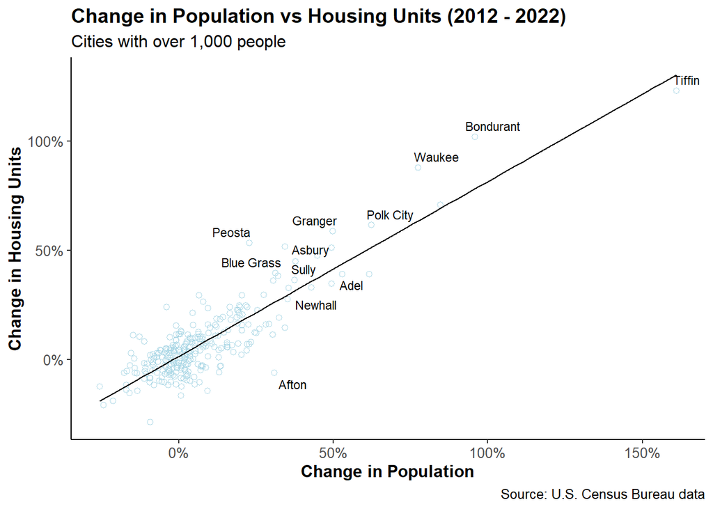

```r
library(ggplot2)
library(ggrepel)

# Remove overlapping labels
final_data <- final_data %>%
  mutate(label = ifelse(NAME %in% c("Norwalk", "Ankeny", "North Liberty", "Grimes", "Johnston", "Mediapolis", "Melcher-Dallas"), NA, NAME))

# Fit the linear model
model <- lm(housing_change ~ population_change, data = final_data)

# Extract the slope (coefficient for population_change)
slope <- coef(model)[2]
intercept <- coef(model)[1]

# Prepare the line of best fit equation text
fit_equation <- paste0("Housing Change = ", round(intercept, 2), " + ", round(slope, 2), " * Population Change")

# Scatter plot with line of best fit and equation
ggplot(final_data, aes(x = population_change, y = housing_change)) +
  geom_point(size = 1.8, color = "lightblue", shape = 21, fill = NA) +
  geom_smooth(method = "lm", color = "black", se = FALSE, size = 0.4) +
  geom_text_repel(aes(label = label), size = 3) +
  labs(
    title = "Change in Population vs Housing Units (2012 - 2022)",
    subtitle = "Cities with over 1,000 people",
    x = "Change in Population",
    y = "Change in Housing Units",
    caption = "Source: U.S. Census Bureau data"
  ) +
  theme_classic() +
  theme(
    text = element_text(size = 12, family = "Arial"),
    plot.title = element_text(size = 14, face = "bold"),
    axis.title = element_text(face = "bold"),
    axis.text = element_text(size = 10)
  ) +
  scale_x_continuous(labels = scales::percent_format(scale = 1)) +
  scale_y_continuous(labels = scales::percent_format(scale = 1))
```

```r
cat("For every 1% increase in population, we see a", round(slope, 2), "% increase in housing supply.\n")
```

```
## For every 1% increase in population, we see a 0.8 % increase in housing supply.
```

```r
cat(fit_equation, "\n")
```

```
## Housing Change = 1.34 + 0.8 * Population Change
```

### housing and population insight

what we see is that for every 5 new residence in Iowa’s medium to larger cities there is 4 new homes being built over roughly the last decade. Many people would just wrap up there research here and say there is enough houses being built and no housing shortage. But were going to dive deeper to see if there isn’t something more going on.

# Reasons we could still be experiencing a housing shortage in Iowa

## Reason One

#### House deteriorating problem

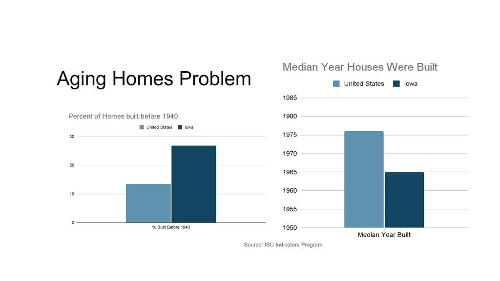

## Reason Two

#### House size potential problem

It’s important to assess changing household size when trying to estimate the housing demand in Iowa. If household size is shrinking, as it is for the entire U.S., then more houses will need to be built to accommodate the same number of total people because fewer people will be living together.

```r
library(tidycensus)
library(dplyr)
library(ggplot2)

# pre 2008 data not avaliable
years <- 2009:2022

# get_acs average household size data
get_household_size <- function(year) {
  get_acs(
    geography = "state",
    variables = "B25010_001",
    year = year,
    survey = "acs5"
  ) %>%
    filter(NAME == "Iowa") %>%
    mutate(year = year)
}

household_size_data <- bind_rows(lapply(years, get_household_size))

# for shaded errorbar
household_size_data <- household_size_data %>%
  mutate(
    lower = estimate - moe,
    upper = estimate + moe
  )

head(household_size_data)
```

```
## # A tibble: 6 × 8
##   GEOID NAME  variable   estimate   moe  year lower upper
##   <chr> <chr> <chr>         <dbl> <dbl> <int> <dbl> <dbl>
## 1 19    Iowa  B25010_001     2.36  0.01  2009  2.35  2.37
## 2 19    Iowa  B25010_001     2.4   0.01  2010  2.39  2.41
## 3 19    Iowa  B25010_001     2.41  0.03  2011  2.38  2.44
## 4 19    Iowa  B25010_001     2.41  0.01  2012  2.4   2.42
## 5 19    Iowa  B25010_001     2.42  0.03  2013  2.39  2.45
## 6 19    Iowa  B25010_001     2.42  0.02  2014  2.4   2.44
```

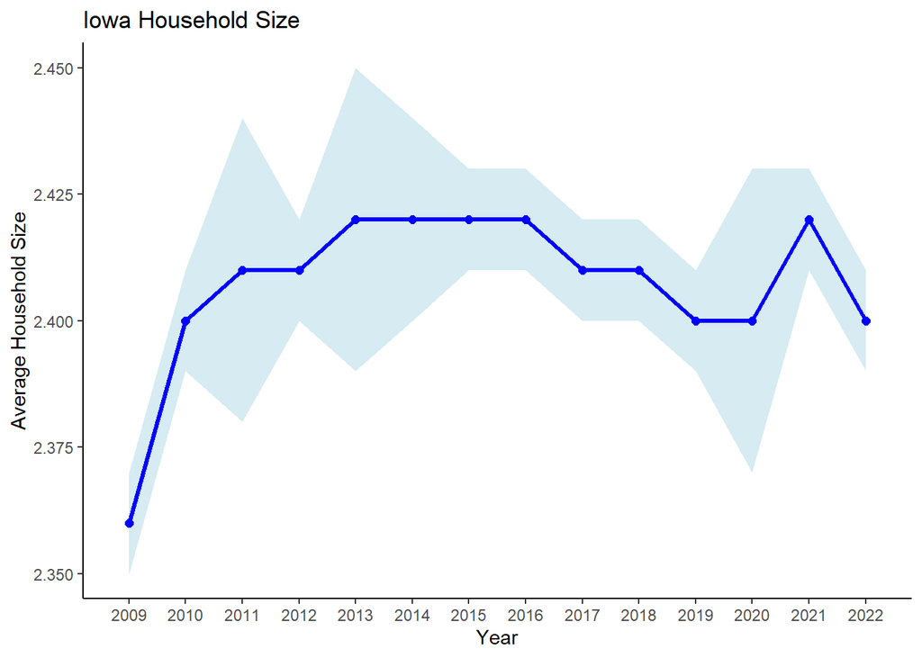

```r
# Time series plot with shaded regions
ggplot(household_size_data, aes(x = year, y = estimate)) +
  geom_ribbon(aes(ymin = lower, ymax = upper), fill = "lightblue", alpha = 0.5) +
  geom_line(size = 1.2, color = "blue") +
  geom_point(size = 2, color = "blue", position = position_dodge(width = 0.3)) +
  labs(
    title = "Iowa Household Size",
    x = "Year",
    y = "Average Household Size"
  ) +
  scale_x_continuous(breaks = seq(min(household_size_data$year), max(household_size_data$year), by = 1)) +
  theme_minimal() +
  theme(
    text = element_text(size = 12, family = "Arial"),
    plot.title = element_text(size = 14, face = "bold"),
    axis.title = element_text(face = "bold"),
    axis.text = element_text(size = 10),
    panel.grid.major = element_blank(),
    panel.grid.minor = element_blank()
  ) +
  theme_classic()
```

Household size for Iowa has been pretty consistent. This means that rising house prices can’t be attributed that much to changing household size for the entire state of Iowa. It may however be the case that some area’s in Iowa aren’t as consistent and need to be further analyzed in more detail.

## Reason Three

### Rising of empty homes problems

Given that people are moving from rural Iowa to more urban areas, it may appear that housing supply is sufficient but actually the houses are in the wrong place and therefore being left vacant.

I will go into what is happening here in the my next analysis because rising vacancy’s has a direct impact on the cost owning a home a deserves it’s own analysis.